# Analisis Perbandingan Profitabilitas Berdasarkan Tipe Produk dan Segmen Pasar pada Dataset Coffee Chain

Fikri Adhiatma Nugroho

2026-04-10

# **Pendahuluan**

## Latar Belakang

Dalam dunia bisnis, pengambilan keputusan yang tepat sangat penting untuk meningkatkan keuntungan perusahaan. Salah satu cara yang dapat dilakukan adalah dengan menganalisis tingkat profitabilitas dari berbagai tipe produk serta melihat perbedaannya pada setiap segmen pasar.

Pada dataset Coffee Chain, terdapat empat tipe produk yaitu Coffee,Espresso, Herbal Tea, dan Tea. Keempat produk ini memiliki karakteristik dan potensi keuntungan yang berbeda. Selain itu, pasar juga dibagi menjadi Major Market dan Small Market yang dapat mempengaruhi tingkat penjualan dan profit.

Oleh karena itu, analisis perbandingan profitabilitas antar tipe produk berdasarkan segmentasi pasar menjadi penting untuk mengetahui kombinasi yang paling menguntungkan dan dapat dijadikan dasar dalam pengambilan keputusan bisnis.

## Rumusan Masalah

1. Bagaimana perbandingan profitabilitas antara Coffee, Espresso, Herbal Tea, dan Tea?
2. Bagaimana pengaruh Market Size terhadap profitabilitas?
3. Kombinasi mana yang paling menguntungkan?

## Tujuan

1. Membandingkan profitabilitas antara Coffee, Espresso, Herbal Tea, dan Tea demi mengetahui product line mana yang paling diminati
2. Menganalisis pengaruh Market Size terhadap penjualan (profit)
3. Menentukan kombinasi terbaik sehingga bisa dijadikan acuan untuk menentukan langkah selanjutnya dan meningkatkan profit

# **Data dan Metodologi**

## Deskripsi Data

Model data yang digunakan dalam dataset ini adalah star schema sederhana, yaitu model yang terdiri dari satu fact table yang terhubung dengan beberapa dimension table. Dataset ini memiliki 3 tabel dengan 1 tabel utama (facttable) dan 2 tabel dimensi (location dan product).

1. Tabel facttable

   Tabel ini adalah data utama yang berisi data transaksi bersifat numerik dan dapat dianalisis, seperti Profit, Sales, COGS, Total Expenses, dan lain lain. Selain itu, tabel ini juga memiliki kunci yang menghubungkan ke tabel dimensi, yaitu kolom ProductId yang menghubungkan tabel facttable ke tabel “product” dan kolom Area Code yang menghubungkan tabel fracttable ke tabel “location”
2. Tabel product

   Berisi informasi terkait produk, seperti ,Product Line (Beans, Leaves), Product Type (Coffee, Espresso, Herbal Tea, dan Tea), dan Product. Berfungsi untuk memberikan kategori produk untuk analisis.
3. Tabel location

   Berisi informasi terkait lokasi atau pasar, seperti State, Market, Market Size (Major, Small), dan lain lain. Berfungsi untuk memberikan konteks wilayah atau segmen pasar.

## Variabel Analisis

Variabel yang digunakan dalam penelitian ini meliputi:

1. Product Type : untuk membedakan jenis tipe produk (Coffee, Espresso, Herbal Tea, dan Tea)
2. Market Size : untuk perbedaan jenis pasar (Major Market dan Small Market)
3. Profit : sebagai indikator utama profitabilitas
4. Sales : sebagai dasar perhitungan kinerja penjualan
5. Profit Margin : dihitung dari perbandingan antara profit dan sales

## Metodologi Analisis

Metode yang digunakan dalam penelitian ini adalah analisis deskriptif kuantitatif dengan tahapan sebagai berikut:

1. Data preparation
2. Pemeriksaan awal data
3. Melakukan analisis deskriptif
4. Visualisasi data
5. Uji Normalitas
6. Melakukan analisis inferensial (ART ANOVA)
7. Uji Lanjut (Post-hoc Analysis menggunakan EM-Means)

# **Tahapan Analisis**

```r
# Memuat paket yang diperlukan untuk koneksi database dan visualisasi
library(DBI)
```

```r
library(ggplot2)
library(ARTool)
library(emmeans)
library(dplyr)
```

## 1. Koneksi Database dan Pengambilan Data

Langkah pertama adalah membangun koneksi antara RStudio dan database MySQL menggunakan fungsi dbConnect()

```r
con2 <- DBI::dbConnect(odbc::odbc(),

Driver = "MySQL ODBC 8.0 ANSI Driver",

Server = "127.0.0.1",

Database = "tugas sim",

UID = "root",

PWD = "nasipadanggg", #sesuaikan dg password masing-masing

Port = 3306)
```

## 2. Data Preparation

Melihat list nama tabel dari dataset

```r
dbListTables(con2)
```

```
## [1] "facttable" "location"  "product"
```

Data diperoleh dari database MySQL yang terdiri dari tiga tabel utama,yaitu factTable, Product, dan Location.

```r
dbGetQuery(con2, "
SELECT *
FROM factTable
LIMIT 10
")
```

```
##    Profit Margin Sales COGS Total Expenses Marketing Inventory Budget Profit
## 1      94    130   219   89             36        24       777           100
## 2      68    107   190   83             39        27       623            80
## 3     101    139   234   95             38        26       821           110
## 4      30     56   100   44             26        14       623            30
## 5      54     80   134   54             26        15       456            70
## 6      53    108   180   72             55        23       558            80
## 7      99    171   341  170             72        47      1091           110
## 8       0     87   150   63             87        57       435            20
## 9      33     80   140   60             47        19       336            40
## 10     17     72   130   58             55        22       338            20
##    Budget COGS Budget Margin Budget Sales Area Code ProductId
## 1           90           130          220       719         1
## 2           80           110          190       970         2
## 3          100           140          240       970         3
```

[output cut: 18 more lines]

```r
dbGetQuery(con2, "
SELECT *
FROM location
LIMIT 10
")
```

```
##    Area Code       State  Market  Market Size
## 1        203 Connecticut    East Small Market
## 2        206  Washington    West Small Market
## 3        209  California    West Major Market
## 4        210       Texas   South Major Market
## 5        212    New York    East Major Market
## 6        213  California    West Major Market
## 7        214       Texas   South Major Market
## 8        216        Ohio Central Major Market
## 9        217    Illinois Central Major Market
## 10       224    Illinois Central Major Market
```

```r
dbReadTable(con2, "product")
```

```
##    Product.Line Product.Type           Product ProductId    Type
## 1         Beans       Coffee          Amaretto         1 Regular
## 2         Beans       Coffee         Colombian         2 Regular
## 3         Beans       Coffee Decaf Irish Cream         3   Decaf
## 4         Beans     Espresso       Caffe Latte         4 Regular
## 5         Beans     Espresso       Caffe Mocha         5 Regular
## 6         Beans     Espresso    Decaf Espresso         6   Decaf
## 7         Beans     Espresso  Regular Espresso         7 Regular
## 8        Leaves   Herbal Tea         Chamomile         8   Decaf
## 9        Leaves   Herbal Tea             Lemon         9   Decaf
## 10       Leaves   Herbal Tea              Mint        10   Decaf
## 11       Leaves          Tea        Darjeeling        11 Regular
## 12       Leaves          Tea         Earl Grey        12 Regular
## 13       Leaves          Tea         Green Tea        13 Regular
```

Ketiga tabel tersebut digabungkan menggunakan operasi join berdasarkan variabel ProductId dan Area Code untuk menghasilkan dataset yang komprehensif. Dataset hasil penggabungan memuat informasi terkait profit, jenis produk, serta ukuran pasar, yang kemudian digunakan sebagai dasar dalam analisis.

```r
data_join <- dbGetQuery(con2, "
SELECT
    f.Date,
    f.ProductId,
    f.Profit,
    f.Margin,
    f.Sales,
    f.Marketing,
    f.`Area Code`,


    p.`Product Line`,
    p.`Product Type`,
    p.Product,

    l.State,
    l.Market,
    l.`Market Size`

FROM factTable f
JOIN Product p ON f.ProductId = p.ProductId
JOIN Location l ON f.`Area Code` = l.`Area Code`
")
head(data_join, 10)
```

```
##                   Date ProductId Profit Margin Sales Marketing Area Code
## 1  2012-01-01 00:00:00         1     94    130   219        24       719
## 2  2012-01-01 00:00:00         2     68    107   190        27       970
## 3  2012-01-01 00:00:00         3    101    139   234        26       970
## 4  2012-01-01 00:00:00        13     30     56   100        14       303
## 5  2012-01-01 00:00:00         5     54     80   134        15       303
## 6  2012-01-01 00:00:00         6     53    108   180        23       720
## 7  2012-01-01 00:00:00         8     99    171   341        47       970
## 8  2012-01-01 00:00:00         9      0     87   150        57       719
## 9  2012-01-01 00:00:00        10     33     80   140        19       970
## 10 2012-01-01 00:00:00        11     17     72   130        22       719
##    Product Line Product Type           Product    State  Market  Market Size
## 1         Beans       Coffee          Amaretto Colorado Central Major Market
## 2         Beans       Coffee         Colombian Colorado Central Major Market
## 3         Beans       Coffee Decaf Irish Cream Colorado Central Major Market
## 4        Leaves          Tea         Green Tea Colorado Central Major Market
## 5         Beans     Espresso       Caffe Mocha Colorado Central Major Market
## 6         Beans     Espresso    Decaf Espresso Colorado Central Major Market
## 7        Leaves   Herbal Tea         Chamomile Colorado Central Major Market
## 8        Leaves   Herbal Tea             Lemon Colorado Central Major Market
## 9        Leaves   Herbal Tea              Mint Colorado Central Major Market
## 10       Leaves          Tea        Darjeeling Colorado Central Major Market
```

Selanjutnya dilakukan eksplorasi awal untuk memahami struktur data serta memastikan kualitas data. Pemeriksaan ini mencakup:

1. identifikasi tipe variabel
2. serta pengecekan adanya nilai hilang (missing value)

```r
str(data_join)
```

```
## 'data.frame':    4248 obs. of  13 variables:
##  $ Date        : chr  "2012-01-01 00:00:00" "2012-01-01 00:00:00" "2012-01-01 00:00:00" "2012-01-01 00:00:00" ...
##  $ ProductId   : int  1 2 3 13 5 6 8 9 10 11 ...
##  $ Profit      : int  94 68 101 30 54 53 99 0 33 17 ...
##  $ Margin      : int  130 107 139 56 80 108 171 87 80 72 ...
##  $ Sales       : int  219 190 234 100 134 180 341 150 140 130 ...
##  $ Marketing   : int  24 27 26 14 15 23 47 57 19 22 ...
##  $ Area Code   : int  719 970 970 303 303 720 970 719 970 719 ...
##  $ Product Line: chr  "Beans" "Beans" "Beans" "Leaves" ...
##  $ Product Type: chr  "Coffee" "Coffee" "Coffee" "Tea" ...
##  $ Product     : chr  "Amaretto" "Colombian" "Decaf Irish Cream" "Green Tea" ...
##  $ State       : chr  "Colorado" "Colorado" "Colorado" "Colorado" ...
##  $ Market      : chr  "Central" "Central" "Central" "Central" ...
##  $ Market Size : chr  "Major Market" "Major Market" "Major Market" "Major Market" ...
```

```r
cek_null <- dbGetQuery(con2, "
SELECT *
FROM factTable
WHERE Profit IS NULL
")
print(paste("Missing value =", nrow(cek_null)))
```

```
## [1] "Missing value = 0"
```

Hasil menunjukkan bahwa tidak terdapat nilai kosong pada variabel Profit, sehingga data layak digunakan untuk analisis lebih lanjut.

## 3. Analisis Deskriptif

Analisis deskriptif dilakukan untuk melihat gambaran umum profitabilitas berdasarkan Product Type dan Market Size. Beberapa ukuran yang digunakan antara lain:

1. Analisis Profit Margin pada Tingkat Observasi (data_margin)

   Analisis awal dilakukan dengan menghitung profit margin pada tingkat observasi, yaitu perbandingan antara profit dan sales pada setiap transaksi. Perhitungan ini bertujuan untuk melihat efisiensi masing-masing produk dalam menghasilkan keuntungan relatif terhadap penjualannya. Hasil perhitungan menunjukkan bahwa terdapat variasi nilai profit margin antar produk. Hal ini mengindikasikan bahwa tidak semua produk memiliki tingkat efisiensi yang sama dalam menghasilkan profit dari setiap unit penjualan.

```r
data_margin <- dbGetQuery(con2, "
SELECT
    f.ProductId,
    p.`Product Type`              AS ProductType,
    f.Profit,
    f.Sales,
    f.Profit * 1.0 / f.Sales     AS Profit_Margin
FROM factTable f
JOIN Product p ON f.ProductId = p.ProductId
")
head(data_margin, 10)
```

```
##    ProductId ProductType Profit Sales Profit_Margin
## 1          1      Coffee     94   219       0.42922
## 2          2      Coffee     68   190       0.35789
## 3          3      Coffee    101   234       0.43162
## 4         13         Tea     30   100       0.30000
## 5          5    Espresso     54   134       0.40299
## 6          6    Espresso     53   180       0.29444
## 7          8  Herbal Tea     99   341       0.29032
## 8          9  Herbal Tea      0   150       0.00000
## 9         10  Herbal Tea     33   140       0.23571
## 10        11         Tea     17   130       0.13077
```

2. Analisis Total Profit per Product Type (total_profit)

   Selanjutnya dilakukan agregasi data untuk menghitung total profit yang dihasilkan oleh masing-masing Product Type. Analisis ini bertujuan untuk mengetahui kontribusi setiap jenis produk terhadap keseluruhan keuntungan perusahaan. Hasil menunjukkan bahwa terdapat perbedaan total profit yang cukup signifikan antar produk. Beberapa produk memberikan kontribusi profit yang lebih besar dibandingkan produk lainnya, yang menunjukkan bahwavolume penjualan dan skala distribusi juga berperan penting dalam menentukan total keuntungan.

```r
total_profit <- dbGetQuery(con2, "
SELECT
    p.`Product Type` AS ProductType,
    SUM(f.Profit) AS Total_Profit
FROM factTable f
JOIN Product p ON f.ProductId = p.ProductId
GROUP BY p.`Product Type`
ORDER BY Total_Profit DESC
")
total_profit
```

```
##   ProductType Total_Profit
## 1      Coffee        74683
## 2    Espresso        68620
## 3  Herbal Tea        63254
## 4         Tea        52986
```

3. Analisis Gabungan antara Product Type dan Market Size (analisis_utama)

   Untuk mendapatkan gambaran yang lebih komprehensif, dilakukan analisis gabungan berdasarkan Product Type dan Market Size. Pada tahap ini dihitung beberapa ukuran, yaitu:
   - jumlah data (N),
   - total profit,
   - rata-rata profit,
   - total sales,
   - serta profit margin.

```r
analisis_utama <- dbGetQuery(con2, "
SELECT
    p.`Product Type` AS ProductType,
    l.`Market Size` AS MarketSize,
    COUNT(*) AS N,
    SUM(f.Profit) AS Total_Profit,
    AVG(f.Profit) AS Avg_Profit,
    SUM(f.Sales) AS Total_Sales,
    SUM(f.Profit) * 1.0 / SUM(f.Sales) AS Profit_Margin
FROM factTable f
JOIN Product p ON f.ProductId = p.ProductId
JOIN Location l ON f.`Area Code` = l.`Area Code`
GROUP BY p.`Product Type`, l.`Market Size`
ORDER BY Profit_Margin DESC
")
analisis_utama
```

```
##   ProductType   MarketSize   N Total_Profit Avg_Profit Total_Sales
## 1         Tea Major Market 408        30770    75.4167       70560
## 2      Coffee Major Market 408        53130   130.2206      127997
## 3    Espresso Major Market 432        42811    99.0995      133065
## 4  Herbal Tea Major Market 456        29025    63.6513       93519
## 5  Herbal Tea Small Market 600        34229    57.0483      113695
## 6    Espresso Small Market 744        25809    34.6895       89931
## 7      Coffee Small Market 648        21553    33.2608       88831
## 8         Tea Small Market 552        22216    40.2464      102213
##   Profit_Margin
## 1       0.43608
## 2       0.41509
## 3       0.32173
## 4       0.31036
## 5       0.30106
## 6       0.28699
## 7       0.24263
## 8       0.21735
```

Hasil analisis menunjukkan bahwa:

- terdapat perbedaan profitabilitas antar jenis produk pada masing-masing ukuran pasar,
- produk tertentu memiliki performa yang lebih baik pada Major Market,
- sementara produk lainnya lebih optimal pada Small Market.

Selain itu, perbedaan nilai profit margin antar kombinasi menunjukkan bahwa efisiensi dan kontribusi profit tidak selalu sejalan. Produk dengan margin tinggi belum tentu menghasilkan total profit tertinggi, dan sebaliknya.

Berdasarkan ketiga analisis tersebut, dapat disimpulkan bahwa:

- Terdapat variasi efisiensi (profit margin) antar produk
- Terdapat perbedaan kontribusi total profit antar produk
- Performa produk dipengaruhi oleh segmen pasar
- Tidak ada satu produk yang unggul secara konsisten di semua kondisi

Hal ini menunjukkan bahwa analisis profitabilitas perlu mempertimbangkan baik aspek efisiensi maupun volume penjualan, serta karakteristik pasar.

## 4. Visualisasi Data

Visualisasi dilakukan menggunakan grafik batang untuk membandingkan profit margin serta total profit antar produk pada masing-masing ukuran pasar.

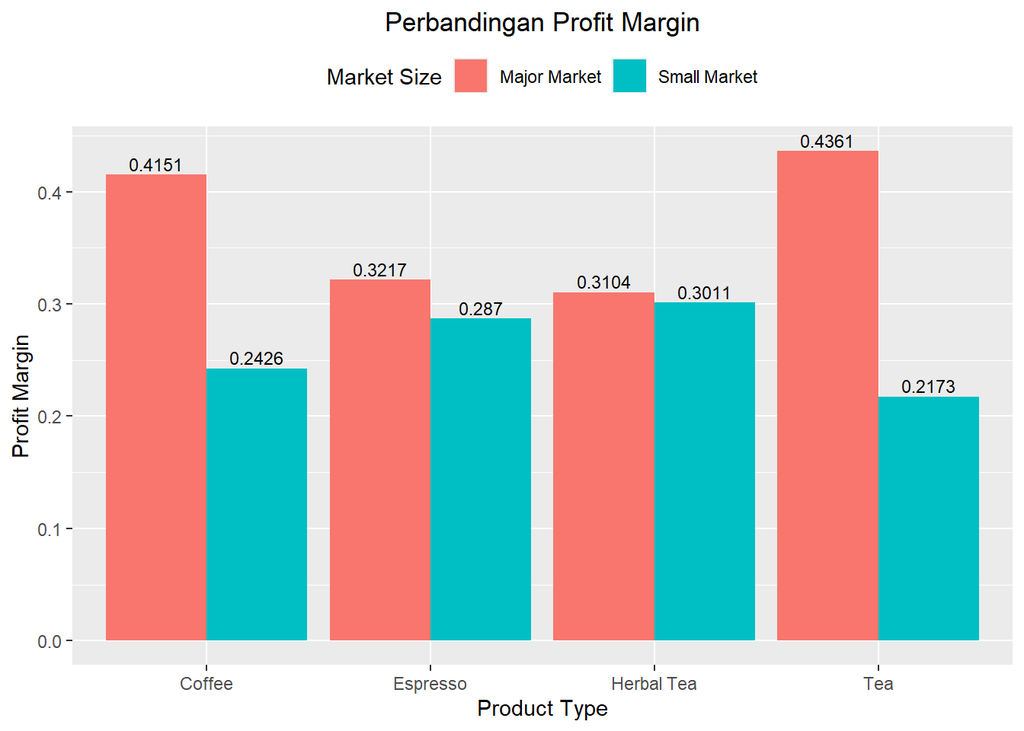

```r
ggplot(analisis_utama, aes(x = ProductType, y = Profit_Margin, fill = MarketSize)) +
  geom_bar(stat = "identity", position = position_dodge()) +
  geom_text(aes(label = round(Profit_Margin, 4)),
            position = position_dodge(width = 0.9),
            vjust = -0.3, size = 3) +
  labs(
    title = "Perbandingan Profit Margin",
    x = "Product Type",
    y = "Profit Margin",
    fill = "Market Size"
  ) +
  theme(
  plot.title = element_text(hjust = 0.5),
  legend.position = "top"
)
```

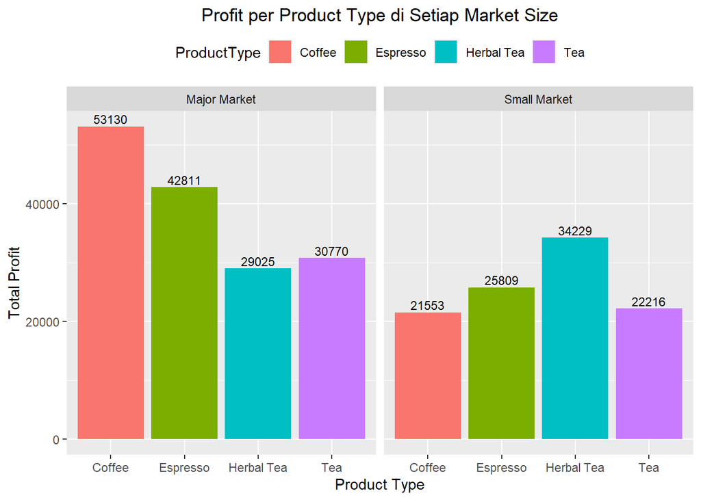

```r
ggplot(analisis_utama, aes(x = ProductType, y = Total_Profit, fill = ProductType)) +
  geom_bar(stat = "identity") +
  geom_text(aes(label = round(Total_Profit, 0)),
            vjust = -0.3, size = 3) +
  facet_wrap(~MarketSize) +
  labs(
    title = "Profit per Product Type di Setiap Market Size",
    x = "Product Type",
    y = "Total Profit"
  ) +
  theme(
  plot.title = element_text(hjust = 0.5),
  legend.position = "top"
)
```

Hasil visualisasi menunjukkan bahwa:

- pada Major Market, produk seperti Coffee dan Espresso cenderung memiliki profit yang lebih tinggi,
- sedangkan pada Small Market, produk seperti Herbal Tea menunjukkan performa yang relatif lebih baik.

Temuan ini mengindikasikan bahwa kinerja produk tidak bersifat universal, melainkan bergantung pada ukuran pasar.

## 5. Uji Normalitas

Uji normalitas dilakukan menggunakan metode Shapiro-Wilk untuk mengetahui distribusi data. Kemudian menentukan langkah uji selanjutnya

```r
uji_normalitas <- shapiro.test(data_join$Profit)
uji_normalitas
```

```
##
##  Shapiro-Wilk normality test
##
## data:  data_join$Profit
## W = 0.79969, p-value < 2.2e-16
```

```r
if (uji_normalitas$p.value > 0.05) {
  print(paste("H0 gagal ditolak: artinya data berdistribusi normal sehingga menggunakan two-way ANOVA"))
} else if (uji_normalitas$p.value < 0.05) {
  print(paste("H0 ditolak: artinya data tidak berdistribusi normal sehingga menggunakan ART ANOVA (non-parametrik)"))
}
```

```
## [1] "H0 ditolak: artinya data tidak berdistribusi normal sehingga menggunakan ART ANOVA (non-parametrik)"
```

Hasil uji menunjukkan bahwa data Profit tidak berdistribusi normal (p-value < 0.05). Oleh karena itu, analisis dilanjutkan menggunakan metode non-parametrik, yaitu Aligned Rank Transform (ART).

## 6. Analisis Inferensial (ART ANOVA)

Dilakukan perubahan tipe data pada variabel Product Type dan Market Size menjadi tipe factor. Perubahan ini bertujuan untuk memastikan bahwa kedua variabel tersebut diperlakukan sebagai variabel kategorik dalam proses analisis.

Dengan mengubahnya menjadi factor, model statistik dapat mengenali bahwa variabel tersebut merupakan kelompok kategori, sehingga dapat digunakan untuk membandingkan perbedaan antar kelompok serta menganalisis interaksi antara jenis produk dan ukuran pasar.

```r
data_join$`Product Type` <- as.factor(data_join$`Product Type`)
data_join$`Market Size`  <- as.factor(data_join$`Market Size`)
```

Analisis menggunakan ART ANOVA dilakukan untuk menguji:

- pengaruh Product Type terhadap profit,
- pengaruh Market Size terhadap profit,
- serta interaksi antara keduanya.

```r
library(dplyr)

data_join <- data_join %>%
  rename(
    Product_Type = `Product Type`,
    Market_Size  = `Market Size`
  )

model_art <- art(Profit ~ Product_Type * Market_Size, data = data_join)
anova(model_art)
```

```
## Analysis of Variance of Aligned Rank Transformed Data
##
## Table Type: Anova Table (Type III tests)
## Model: No Repeated Measures (lm)
## Response: art(Profit)
##
##                            Df Df.res F value     Pr(>F)
## 1 Product_Type              3   4240  13.675 7.0941e-09 ***
## 2 Market_Size               1   4240 618.667 < 2.22e-16 ***
## 3 Product_Type:Market_Size  3   4240  54.923 < 2.22e-16 ***
## ---
## Signif. codes:   0 '***' 0.001 '**' 0.01 '*' 0.05 '.' 0.1 ' ' 1
```

```r
hasil <- anova(model_art)

p_product  <- hasil$`Pr(>F)`[1]
p_market   <- hasil$`Pr(>F)`[2]
p_interaksi<- hasil$`Pr(>F)`[3]

# Kesimpulan
if (p_product < 0.05) {
  print("Product Type berpengaruh signifikan terhadap Profit")
} else {
  print("Product Type tidak berpengaruh signifikan terhadap Profit")
}
```

```
## [1] "Product Type berpengaruh signifikan terhadap Profit"
```

```r
if (p_market < 0.05) {
  print("Market Size berpengaruh signifikan terhadap Profit")
} else {
  print("Market Size tidak berpengaruh signifikan terhadap Profit")
}
```

```
## [1] "Market Size berpengaruh signifikan terhadap Profit"
```

```r
if (p_interaksi < 0.05) {
  print("Terdapat interaksi signifikan antara Product Type dan Market Size terhadap Profit")
} else {
  print("Tidak terdapat interaksi signifikan antara Product Type dan Market Size")
}
```

```
## [1] "Terdapat interaksi signifikan antara Product Type dan Market Size terhadap Profit"
```

Hasil pengujian menunjukkan bahwa:

1. Product Type berpengaruh signifikan terhadap profit,
2. Market Size berpengaruh signifikan terhadap profit,
3. dan terdapat interaksi signifikan antara Product Type dan Market Size.

Interaksi ini menunjukkan bahwa pengaruh jenis produk terhadap profit tidak konsisten pada semua ukuran pasar.

## 7. Uji Lanjut (Post-hoc Analysis)

Karena terdapat interaksi yang signifikan, dilakukan uji lanjut menggunakan metode Estimated Marginal Means untuk mengidentifikasi produk dengan profit tertinggi pada masing-masing ukuran pasar.

```r
library(dplyr)
library(emmeans)


# ANOVA
hasil <- anova(model_art)

p_interaksi <- hasil$`Pr(>F)`[3]

# EMMEANS untuk pola
model_art_lm <- artlm(model_art, "Product_Type:Market_Size")

em <- emmeans(model_art_lm, ~ Product_Type | Market_Size)
em_df <- as.data.frame(em)

top_produk <- em_df %>%
  group_by(Market_Size) %>%
  slice_max(emmean, n = 1)

# Kesimpulan
if (p_interaksi < 0.05) {
  cat("Terdapat interaksi signifikan antara Product Type dan Market Size terhadap Profit.\n")

  cat("Produk dengan profit tertinggi pada tiap Market Size adalah:\n")
  print(top_produk)

  cat("Hal ini menunjukkan bahwa produk yang paling menguntungkan berbeda pada setiap ukuran pasar.\n")

} else {
  cat("Tidak terdapat interaksi signifikan antara Product Type dan Market Size.\n")
}
```

```
## Terdapat interaksi signifikan antara Product Type dan Market Size terhadap Profit.
## Produk dengan profit tertinggi pada tiap Market Size adalah:
## # A tibble: 2 × 7
## # Groups:   Market_Size [2]
##   Product_Type Market_Size  emmean    SE    df lower.CL upper.CL
##   <fct>        <fct>         <dbl> <dbl> <dbl>    <dbl>    <dbl>
## 1 Espresso     Major Market  2270.  57.6  4240    2157.    2383.
## 2 Herbal Tea   Small Market  2446.  48.9  4240    2350.    2542.
## Hal ini menunjukkan bahwa produk yang paling menguntungkan berbeda pada setiap ukuran pasar.
```

Hasil uji lanjut menunjukkan bahwa:

- pada Major Market, produk Coffee dan Espresso memiliki profit yang relatif tinggi,
- sedangkan pada Small Market, produk Herbal Tea memiliki profit tertinggi.

Temuan ini memperkuat bahwa strategi produk harus disesuaikan dengan karakteristik pasar.

# **Kesimpulan**

Berdasarkan hasil analisis, terdapat perbedaan profitabilitas antara Coffee, Espresso, Herbal Tea, dan Tea. Product Type dan Market Size terbukti berpengaruh signifikan terhadap profit, serta terdapat interaksi antara keduanya.

Pada Major Market, produk Coffee dan Espresso menunjukkan profit yang relatif lebih tinggi dibandingkan produk lainnya. Sementara itu, pada Small Market, produk Herbal Tea memiliki profit tertinggi.

Dengan demikian, kombinasi yang paling menguntungkan berbeda pada setiap ukuran pasar, yaitu **Coffee/Espresso pada Major Market** dan **Herbal Tea pada Small Market**. Hal ini menunjukkan bahwa strategi bisnis perlu disesuaikan dengan karakteristik pasar untuk memaksimalkan profit.

# **Implikasi**

Berdasarkan hasil analisis yang telah dilakukan, terdapat beberapa implikasi yang dapat dijadikan dasar dalam pengambilan keputusan bisnis.

1. Pertama, perusahaan tidak dapat menerapkan satu strategi produk untuk semua jenis pasar. Hal ini disebabkan oleh adanya perbedaan performa produk pada masing-masing ukuran pasar.
2. Kedua, pada Major Market, produk seperti Coffee dan Espresso terbukti memiliki profit yang lebih tinggi, sehingga perusahaan sebaiknya memfokuskan distribusi dan strategi pemasaran pada produk tersebut di pasar besar.
3. Ketiga, pada Small Market, produk Herbal Tea menunjukkan performa profit yang lebih baik dibandingkan produk lainnya. Oleh karena itu, strategi pemasaran di pasar kecil sebaiknya lebih diarahkan pada produk tersebut.
4. Keempat, perbedaan antara profit margin dan total profit menunjukkan bahwa perusahaan perlu mempertimbangkan tidak hanya efisiensi produk, tetapi juga volume penjualan dalam menentukan strategi bisnis.

Dengan demikian, perusahaan disarankan untuk menerapkan strategi yang berbeda pada setiap segmen pasar guna memaksimalkan profitabilitas secara keseluruhan.